# Isoform-Level DIE Summary: NMD Inhibition Effects

Analysis Pipeline

2026-01-16

# 1 Analysis Overview

This report summarizes Differential Isoform Expression (DIE) results from the NMD inhibition study and performs functional enrichment analysis to identify biological pathways affected by NMD.

**Experimental Design:**

- **Treatment:** Smg1i (NMD inhibitor) vs DMSO (control)
- **Cell Types:** 6 cell types (AT, DD, DD_ALI, DO, FB, MV)
- **Data Type:** Long-read PacBio IsoSeq (isoform-level resolution)
- **Analysis:** limma-voom differential expression at transcript level

**Report Structure:**

1. **Part 1: DIE Summary** - Overview of significant differential isoform expression results
2. **Part 2: Functional Enrichment** - Gene Set Enrichment Analysis (GSEA) using three NMD-responsive gene definitions

# 2 Load Libraries and Configuration

```r
# Set CRAN mirror for package installation
options(repos = c(CRAN = "https://cloud.r-project.org"))

library(tidyverse)
library(data.table)
library(DT)
library(edgeR)

# Check and install fgsea (Bioconductor)
if (!require("fgsea", quietly = TRUE)) {
  if (!require("BiocManager", quietly = TRUE)) {
    install.packages("BiocManager")
  }
  BiocManager::install("fgsea")
  library(fgsea)
}

# Check and install msigdbr (CRAN)
if (!require("msigdbr", quietly = TRUE)) {
  install.packages("msigdbr")
  library(msigdbr)
}

# Check and install pheatmap (CRAN)
if (!require("pheatmap", quietly = TRUE)) {
  install.packages("pheatmap")
  library(pheatmap)
}

library(fgsea)
library(msigdbr)
library(pheatmap)
```

```r
# Date stamp for output files
DATE_STAMP <- "2026.1.15"

# Input paths
INPUT_DIE_DIR <- file.path("..", "longread_dge")
INPUT_GENE_DGE_DIR <- file.path("..", "shortread_dge")
INPUT_DGELIST <- file.path("..", "results", "rds", "dge_isoform_2026.1.3.rds")
OUTPUT_DIR <- file.path("..", "tmp")

# Cell type mapping
CELLTYPE_MAP <- c(
  "at2" = "AT", "dd" = "DD", "ddali" = "DD_ALI",
  "doali" = "DO", "fb" = "FB", "mv" = "MV"
)

# Analysis thresholds
SIGNIFICANCE_THRESHOLD <- 0.05
LOGFC_THRESHOLD <- 0  # For NMD-responsive (upregulated)
TOP_HITS_N <- 50

# GSEA parameters
GSEA_MIN_SIZE <- 15
GSEA_MAX_SIZE <- 500
GSEA_NPERM <- 10000

cat("Configuration loaded successfully\n")
```

```
## Configuration loaded successfully
```

```r
cat("Date stamp:", DATE_STAMP, "\n")
```

```
## Date stamp: 2026.1.15
```

```r
cat("Output directory:", OUTPUT_DIR, "\n")
```

```
## Output directory: ../tmp
```

# 3 PART 1: DIE Summary

## 3.1 Load Isoform-Level DIE Results

```r
cat("Loading isoform-level DIE results from longread_dge/...\n\n")
```

```
## Loading isoform-level DIE results from longread_dge/...
```

```r
# Load all DIE files
die_files <- list.files(INPUT_DIE_DIR,
                        pattern = "^nmd_dge_.*_2026\\.1\\.2\\.csv$",
                        full.names = TRUE)

cat("Found", length(die_files), "DIE files:\n")
```

```
## Found 6 DIE files:
```

```r
print(basename(die_files))
```

```
## [1] "nmd_dge_at2_2026.1.2.csv"   "nmd_dge_dd_2026.1.2.csv"
## [3] "nmd_dge_ddali_2026.1.2.csv" "nmd_dge_doali_2026.1.2.csv"
## [5] "nmd_dge_fb_2026.1.2.csv"    "nmd_dge_mv_2026.1.2.csv"
```

```r
cat("\n")
```

```r
# First pass: count transcripts in each file
original_counts <- map_df(die_files, ~{
  # Extract cell type from filename
  basename_file <- basename(.x)
  parts <- str_split(basename_file, "_")[[1]]
  celltype <- parts[3]  # "at2", "dd", "ddali", etc.

  # Count lines in file (subtract 1 for header)
  n_lines <- as.numeric(system(paste0("wc -l < '", .x, "'"), intern = TRUE))
  n_transcripts <- n_lines - 1

  tibble(
    cell_type_file = celltype,
    cell_type = CELLTYPE_MAP[celltype],
    original_count = n_transcripts
  )
})

cat("\nOriginal transcript counts per file:\n")
```

```
##
## Original transcript counts per file:
```

```r
print(original_counts)
```

```
## # A tibble: 6 × 3
##   cell_type_file cell_type original_count
##   <chr>          <chr>              <dbl>
## 1 at2            AT                291565
## 2 dd             DD                291565
## 3 ddali          DD_ALI            291565
## 4 doali          DO                291565
## 5 fb             FB                291565
## 6 mv             MV                291565
```

```r
cat("\n")
```

```r
# Second pass: load and combine data
all_dge <- map_df(die_files, ~{
  df <- read_csv(.x, show_col_types = FALSE)

  # Extract cell type from filename
  basename_file <- basename(.x)
  parts <- str_split(basename_file, "_")[[1]]
  celltype <- parts[3]  # "at2", "dd", "ddali", etc.

  df$cell_type_file <- celltype
  df
})

# Map to display names
all_dge$cell_type <- CELLTYPE_MAP[all_dge$cell_type_file]
all_dge <- all_dge %>% filter(!is.na(cell_type))

cat("Combined DIE data:\n")
```

```
## Combined DIE data:
```

```r
cat("- Total rows:", nrow(all_dge), "\n")
```

```
## - Total rows: 1749390
```

```r
cat("- Transcripts per cell type:", nrow(all_dge) / length(unique(all_dge$cell_type)), "\n")
```

```
## - Transcripts per cell type: 291565
```

```r
cat("- Cell types:", paste(unique(all_dge$cell_type), collapse = ", "), "\n")
```

```
## - Cell types: AT, DD, DD_ALI, DO, FB, MV
```

```r
cat("\n")
```

```r
# Rename txid column if needed for consistency
if (!"transcript_id" %in% colnames(all_dge) && "txid" %in% colnames(all_dge)) {
  all_dge <- all_dge %>% rename(transcript_id = txid)
}
```

## 3.2 Add Gene Symbols

```r
cat("## Loading gene symbols from shortread_dge/\n\n")
```

```
## ## Loading gene symbols from shortread_dge/
```

```r
# Load gene-level DGE files to extract gene symbols
gene_dge_files <- list.files(INPUT_GENE_DGE_DIR,
                              pattern = "^nmd_sr_dge_.*_2026\\.1\\.2\\.csv$",
                              full.names = TRUE)

cat("Found", length(gene_dge_files), "gene-level DGE files for gene symbol mapping\n\n")
```

```
## Found 6 gene-level DGE files for gene symbol mapping
```

```r
gene_dge_for_symbols <- map_df(gene_dge_files, ~{
  read_csv(.x, show_col_types = FALSE) %>%
    select(ensembl_gene_id_version, hgnc_symbol)
})

# Create gene symbol mapping (Ensembl ID without version -> gene symbol)
gene_symbol_map <- gene_dge_for_symbols %>%
  mutate(gene_id_no_version = str_replace(ensembl_gene_id_version, "\\.\\d+$", "")) %>%
  select(gene_id_no_version, hgnc_symbol) %>%
  distinct()

cat("Created gene symbol mapping:", nrow(gene_symbol_map), "genes\n\n")
```

```
## Created gene symbol mapping: 20730 genes
```

```r
# Add gene symbols to all_dge
all_dge <- all_dge %>%
  left_join(gene_symbol_map, by = c("hgnc_id" = "gene_id_no_version")) %>%
  mutate(gene_symbol = coalesce(hgnc_symbol, hgnc_id))  # Use symbol if available, otherwise Ensembl ID

cat("Added gene symbols to DIE data\n")
```

```
## Added gene symbols to DIE data
```

```r
cat("- Transcripts with gene symbols:", sum(!is.na(all_dge$hgnc_symbol)), "\n")
```

```
## - Transcripts with gene symbols: 935202
```

```r
cat("- Transcripts without gene symbols:", sum(is.na(all_dge$hgnc_symbol)), "\n\n")
```

```
## - Transcripts without gene symbols: 814188
```

## 3.3 Overall Summary Statistics

```r
cat("## DIE Summary Statistics by Cell Type\n\n")
```

```
## ## DIE Summary Statistics by Cell Type
```

```r
die_summary <- all_dge %>%
  group_by(cell_type) %>%
  summarize(
    sig_transcripts = sum(adj.P.Val < SIGNIFICANCE_THRESHOLD, na.rm = TRUE),
    nmd_responsive = sum(adj.P.Val < SIGNIFICANCE_THRESHOLD & logFC > LOGFC_THRESHOLD, na.rm = TRUE),
    nmd_suppressed = sum(adj.P.Val < SIGNIFICANCE_THRESHOLD & logFC < -LOGFC_THRESHOLD, na.rm = TRUE),
    mean_logFC_nmd = mean(logFC[adj.P.Val < SIGNIFICANCE_THRESHOLD & logFC > LOGFC_THRESHOLD], na.rm = TRUE),
    median_logFC_nmd = median(logFC[adj.P.Val < SIGNIFICANCE_THRESHOLD & logFC > LOGFC_THRESHOLD], na.rm = TRUE),
    .groups = "drop"
  ) %>%
  left_join(original_counts %>% select(cell_type, original_count), by = "cell_type") %>%
  rename(total_transcripts = original_count) %>%
  mutate(
    pct_sig = 100 * sig_transcripts / total_transcripts,
    pct_nmd_responsive = 100 * nmd_responsive / sig_transcripts
  ) %>%
  select(cell_type, total_transcripts, sig_transcripts, nmd_responsive, nmd_suppressed,
         pct_sig, pct_nmd_responsive, mean_logFC_nmd, median_logFC_nmd)

cat("**Table 1. DIE Summary Statistics by Cell Type**\n\n")
```

```
## **Table 1. DIE Summary Statistics by Cell Type**
```

```r
cat("Column definitions:\n")
```

```
## Column definitions:
```

```r
cat("- **cell_type**: Cell type identifier\n")
```

```
## - **cell_type**: Cell type identifier
```

```r
cat("- **total_transcripts**: Total number of transcripts tested in original DIE analysis\n")
```

```
## - **total_transcripts**: Total number of transcripts tested in original DIE analysis
```

```r
cat("- **sig_transcripts**: Number of transcripts with adjusted p-value < 0.05\n")
```

```
## - **sig_transcripts**: Number of transcripts with adjusted p-value < 0.05
```

```r
cat("- **nmd_responsive**: Number of transcripts significantly upregulated (logFC > 0, adj.P.Val < 0.05)\n")
```

```
## - **nmd_responsive**: Number of transcripts significantly upregulated (logFC > 0, adj.P.Val < 0.05)
```

```r
cat("- **nmd_suppressed**: Number of transcripts significantly downregulated (logFC < 0, adj.P.Val < 0.05)\n")
```

```
## - **nmd_suppressed**: Number of transcripts significantly downregulated (logFC < 0, adj.P.Val < 0.05)
```

```r
cat("- **pct_sig**: Percentage of significant transcripts (out of total transcripts tested)\n")
```

```
## - **pct_sig**: Percentage of significant transcripts (out of total transcripts tested)
```

```r
cat("- **pct_nmd_responsive**: Percentage of NMD-responsive transcripts (out of significant transcripts)\n")
```

```
## - **pct_nmd_responsive**: Percentage of NMD-responsive transcripts (out of significant transcripts)
```

```r
cat("- **mean_logFC_nmd**: Mean log2 fold change of NMD-responsive transcripts\n")
```

```
## - **mean_logFC_nmd**: Mean log2 fold change of NMD-responsive transcripts
```

```r
cat("- **median_logFC_nmd**: Median log2 fold change of NMD-responsive transcripts\n\n")
```

```
## - **median_logFC_nmd**: Median log2 fold change of NMD-responsive transcripts
```

```r
datatable(die_summary,
          options = list(pageLength = 10),
          caption = "Table 1. DIE Summary: Significant transcripts and NMD-responsive counts per cell type") %>%
  formatRound(columns = c("pct_sig", "pct_nmd_responsive", "mean_logFC_nmd", "median_logFC_nmd"), digits = 2)
```

|  | cell_type | total_transcripts | sig_transcripts | nmd_responsive | nmd_suppressed | pct_sig | pct_nmd_responsive | mean_logFC_nmd | median_logFC_nmd |
| --- | --- | --- | --- | --- | --- | --- | --- | --- | --- |
| 1 | AT | 291565 | 6428 | 6002 | 426 | 2.204654193747535 | 93.3727442439328 | 3.446191269576808 | 3.36 |
| 2 | DD | 291565 | 28666 | 26358 | 2308 | 9.831769931233172 | 91.94864996860392 | 3.337969269292056 | 3.233 |
| 3 | DD_ALI | 291565 | 18373 | 15841 | 2532 | 6.301510812340301 | 86.21890818048223 | 3.354945521116091 | 3.165 |
| 4 | DO | 291565 | 6 | 1 | 5 | 0.002057860168401557 | 16.66666666666667 | 4.817 | 4.817 |
| 5 | FB | 291565 | 2383 | 2272 | 111 | 0.8173134635501518 | 95.34200587494755 | 3.453068221830986 | 3.3795 |
| 6 | MV | 291565 | 5019 | 4581 | 438 | 1.721400030867902 | 91.27316198445905 | 3.548945863348613 | 3.427 |

```r
# Save summary table
write_tsv(die_summary, file.path(OUTPUT_DIR, paste0("die_summary_stats_", DATE_STAMP, ".tsv")))
cat("\nSaved:", file.path(OUTPUT_DIR, paste0("die_summary_stats_", DATE_STAMP, ".tsv")), "\n")
```

```
##
## Saved: ../tmp/die_summary_stats_2026.1.15.tsv
```

## 3.4 NMD-Responsive Transcripts

```r
cat("## NMD-Responsive Transcripts (logFC > 0, adj.P.Val < 0.05)\n\n")
```

```
## ## NMD-Responsive Transcripts (logFC > 0, adj.P.Val < 0.05)
```

```r
nmd_responsive <- all_dge %>%
  filter(logFC > LOGFC_THRESHOLD, adj.P.Val < SIGNIFICANCE_THRESHOLD)

cat("Total NMD-responsive transcript-celltype combinations:", nrow(nmd_responsive), "\n")
```

```
## Total NMD-responsive transcript-celltype combinations: 55055
```

```r
cat("Unique NMD-responsive transcripts (across all cell types):", n_distinct(nmd_responsive$transcript_id), "\n\n")
```

```
## Unique NMD-responsive transcripts (across all cell types): 42559
```

```r
# Summary by cell type
nmd_summary <- nmd_responsive %>%
  group_by(cell_type) %>%
  summarize(
    n_transcripts = n(),
    n_genes = n_distinct(hgnc_id, na.rm = TRUE),
    mean_logFC = mean(logFC),
    median_logFC = median(logFC),
    max_logFC = max(logFC),
    mean_AveExpr = mean(AveExpr, na.rm = TRUE),
    .groups = "drop"
  )

cat("\n**Table 2. NMD-Responsive Transcripts by Cell Type**\n\n")
```

```
##
## **Table 2. NMD-Responsive Transcripts by Cell Type**
```

```r
cat("Column definitions:\n")
```

```
## Column definitions:
```

```r
cat("- **cell_type**: Cell type identifier\n")
```

```
## - **cell_type**: Cell type identifier
```

```r
cat("- **n_transcripts**: Number of NMD-responsive transcripts in this cell type (logFC > 0, adj.P.Val < 0.05)\n")
```

```
## - **n_transcripts**: Number of NMD-responsive transcripts in this cell type (logFC > 0, adj.P.Val < 0.05)
```

```r
cat("- **n_genes**: Number of unique genes with NMD-responsive transcripts in this cell type\n")
```

```
## - **n_genes**: Number of unique genes with NMD-responsive transcripts in this cell type
```

```r
cat("- **mean_logFC**: Mean log2 fold change (Smg1i vs DMSO)\n")
```

```
## - **mean_logFC**: Mean log2 fold change (Smg1i vs DMSO)
```

```r
cat("- **median_logFC**: Median log2 fold change\n")
```

```
## - **median_logFC**: Median log2 fold change
```

```r
cat("- **max_logFC**: Maximum log2 fold change\n")
```

```
## - **max_logFC**: Maximum log2 fold change
```

```r
cat("- **mean_AveExpr**: Mean average expression level (log2 CPM)\n\n")
```

```
## - **mean_AveExpr**: Mean average expression level (log2 CPM)
```

```r
datatable(nmd_summary,
          options = list(pageLength = 10),
          caption = "Table 2. NMD-responsive transcripts by cell type") %>%
  formatRound(columns = c("mean_logFC", "median_logFC", "max_logFC", "mean_AveExpr"), digits = 2)
```

|  | cell_type | n_transcripts | n_genes | mean_logFC | median_logFC | max_logFC | mean_AveExpr |
| --- | --- | --- | --- | --- | --- | --- | --- |
| 1 | AT | 6002 | 4337 | 3.446191269576808 | 3.36 | 8.676 | -1.696128676144701 |
| 2 | DD | 26358 | 13701 | 3.337969269292056 | 3.233 | 9.432 | -2.588323848546931 |
| 3 | DD_ALI | 15841 | 8239 | 3.354945521116091 | 3.165 | 14.365 | 0.1875111419733626 |
| 4 | DO | 1 | 1 | 4.817 | 4.817 | 4.817 | -2.97578443552974 |
| 5 | FB | 2272 | 1825 | 3.453068221830986 | 3.3795 | 8.572 | -0.9603495627590083 |
| 6 | MV | 4581 | 3361 | 3.548945863348613 | 3.427 | 9.402 | -1.18751037536272 |

```r
# Save all NMD-responsive transcripts
write_tsv(nmd_responsive, file.path(OUTPUT_DIR, paste0("die_nmd_responsive_all_", DATE_STAMP, ".tsv")))
cat("\nSaved:", file.path(OUTPUT_DIR, paste0("die_nmd_responsive_all_", DATE_STAMP, ".tsv")), "\n")
```

```
##
## Saved: ../tmp/die_nmd_responsive_all_2026.1.15.tsv
```

## 3.5 Top Hits per Cell Type

```r
cat("## Top", TOP_HITS_N, "NMD-Responsive Transcripts per Cell Type\n\n")
```

## 3.6 Top 50 NMD-Responsive Transcripts per Cell Type

```r
library(htmltools)

table_num <- 3  # Starting table number for top hits
tables_list <- list()

for (ct in unique(nmd_responsive$cell_type)) {
  cat("\n###", ct, "\n\n")

  top_hits <- nmd_responsive %>%
    filter(cell_type == ct) %>%
    arrange(adj.P.Val) %>%
    head(TOP_HITS_N) %>%
    select(transcript_id, gene_symbol, transcript.gc, biotype, logFC, adj.P.Val, AveExpr, t, B)

  cat("**Table", table_num, ". Top", TOP_HITS_N, "NMD-Responsive Transcripts in", ct, "**\n\n")
  cat("Column definitions:\n")
  cat("- **transcript_id**: Transcript identifier\n")
  cat("- **gene_symbol**: Gene symbol (HUGO/HGNC)\n")
  cat("- **transcript.gc**: Transcript name from GENCODE annotation\n")
  cat("- **biotype**: Transcript biotype (protein_coding, lncRNA, etc.)\n")
  cat("- **logFC**: Log2 fold change (Smg1i vs DMSO)\n")
  cat("- **adj.P.Val**: FDR-adjusted p-value\n")
  cat("- **AveExpr**: Average expression level (log2 CPM)\n")
  cat("- **t**: t-statistic from differential expression test\n")
  cat("- **B**: B-statistic (log-odds of differential expression)\n\n")

  # Create datatable and add to list
  dt <- datatable(top_hits,
              options = list(pageLength = 10),
              caption = paste0("Table ", table_num, ". Top ", TOP_HITS_N, " NMD-responsive transcripts in ", ct)) %>%
      formatRound(columns = c("logFC", "adj.P.Val", "AveExpr", "t", "B"), digits = 3)

  print(htmltools::tagList(dt))
  cat("\n\n")

  table_num <- table_num + 1

  # Save top hits
  output_file <- file.path(OUTPUT_DIR, paste0("die_top_hits_", tolower(ct), "_", DATE_STAMP, ".tsv"))
  write_tsv(top_hits, output_file)
  cat("\nSaved:", output_file, "\n")
}
```

### 3.6.1 AT

**Table 3 . Top 50 NMD-Responsive Transcripts in AT**

Column definitions: - **transcript_id**: Transcript identifier - **gene_symbol**: Gene symbol (HUGO/HGNC) - **transcript.gc**: Transcript name from GENCODE annotation - **biotype**: Transcript biotype (protein_coding, lncRNA, etc.) - **logFC**: Log2 fold change (Smg1i vs DMSO) - **adj.P.Val**: FDR-adjusted p-value - **AveExpr**: Average expression level (log2 CPM) - **t**: t-statistic from differential expression test - **B**: B-statistic (log-odds of differential expression)

|  | transcript_id | gene_symbol | transcript.gc | biotype | logFC | adj.P.Val | AveExpr | t | B |
| --- | --- | --- | --- | --- | --- | --- | --- | --- | --- |
| 1 | ENST00000455414.3 | ENSG00000226900 | ENST00000455414 | lncRNA | 6.94 | 6.45214795382464e-08 | 1.21871096561409 | 11.8214112207585 | 18.6427365379976 |
| 2 | ENST00000709013.1 | OR5T1 | OR5T1-203 | protein_coding | 6.55 | 6.45214795382464e-08 | 0.746269723213601 | 11.6737541577986 | 18.2933992341293 |
| 3 | PB.17456.179 | GCC2 |  |  | 6.433 | 3.00801845828683e-07 | -1.69627074372455 | 10.7020847154756 | 16.4624973080735 |
| 4 | PB.25552.139 | F2R |  |  | 8.214 | 9.37972174417166e-07 | 0.269386508773614 | 10.0227629866657 | 15.1996542439428 |
| 5 | ENST00000815844.1 | LINC02018 | LINC02018-366 | lncRNA | 5.275 | 9.37972174417166e-07 | -3.8659686991068 | 9.99068982865686 | 14.9106331880906 |
| 6 | PB.20268.57 | RRP1B |  |  | 4.767 | 9.37972174417166e-07 | 3.55399849397563 | 9.93852661177577 | 15.4895929618041 |
| 7 | ENST00000685451.1 | ENSG00000291176 | ENST00000685451 | lncRNA | 6.269 | 9.37972174417166e-07 | -0.30308715205189 | 9.90160687054881 | 14.8153277446325 |
| 8 | ENST00000966931.1 | CTBP2 | CTBP2-311 | protein_coding | 5.437 | 9.37972174417166e-07 | -1.28821658059818 | 9.89395570852287 | 14.7120824596056 |
| 9 | PB.13007.66 | ENSG00000214719 |  |  | 5.756 | 1.53341278130845e-06 | -0.890824842136449 | 9.61500993891111 | 14.1587341943042 |
| 10 | PB.15090.26 | RGL3 |  |  | 4.159 | 2.28845850274826e-06 | 3.46236436106102 | 9.42102246608243 | 14.4133358186095 |

[output cut: 40 more lines]

Saved: ../tmp/die_top_hits_at_2026.1.15.tsv

### 3.6.2 DD

**Table 4 . Top 50 NMD-Responsive Transcripts in DD**

Column definitions: - **transcript_id**: Transcript identifier - **gene_symbol**: Gene symbol (HUGO/HGNC) - **transcript.gc**: Transcript name from GENCODE annotation - **biotype**: Transcript biotype (protein_coding, lncRNA, etc.) - **logFC**: Log2 fold change (Smg1i vs DMSO) - **adj.P.Val**: FDR-adjusted p-value - **AveExpr**: Average expression level (log2 CPM) - **t**: t-statistic from differential expression test - **B**: B-statistic (log-odds of differential expression)

|  | transcript_id | gene_symbol | transcript.gc | biotype | logFC | adj.P.Val | AveExpr | t | B |
| --- | --- | --- | --- | --- | --- | --- | --- | --- | --- |
| 1 | PB.20989.66 | RABL2B |  |  | 5.954 | 3.27595669662475e-10 | 2.619 | 14.556 | 24.8585461723717 |
| 2 | PB.5974.50 | CREBZF |  |  | 6.86 | 4.47377834551038e-10 | -3.45 | 14.039 | 22.9855112389702 |
| 3 | PB.2650.23 | DENND1B |  |  | 5.616 | 4.49522810270542e-10 | 1.201 | 13.701 | 22.9962035364952 |
| 4 | PB.9018.11 | ARGLU1 |  |  | 4.918 | 4.49522810270542e-10 | 6.965 | 13.648 | 23.905377224406 |
| 5 | PB.24941.50 | LPCAT1 |  |  | 8.736 | 4.49522810270542e-10 | -3.123 | 13.527 | 22.2793218686456 |
| 6 | PB.20476.1 | DERL3 |  |  | 6.478 | 4.49522810270542e-10 | -3.748 | 13.387 | 21.960707731579 |
| 7 | ENST00000461034.1 | LINC00595 | LINC00595-207 | lncRNA | 5.095 | 4.49522810270542e-10 | 1.031 | 13.349 | 22.4311016640263 |
| 8 | PB.11762.194 | ATXN2L |  |  | 5.945 | 4.49522810270542e-10 | -3.788 | 13.347 | 21.8662466047162 |
| 9 | ENST00000829021.1 | ENSG00000307815 | ENST00000829021 | lncRNA | 6.262 | 4.50813613955063e-10 | -3.663 | 13.288 | 21.7661849587366 |
| 10 | PB.32652.223 | MFSD14CP |  |  | 5.54 | 5.18298791157669e-10 | 3.184 | 13.145 | 22.4778286721097 |

[output cut: 40 more lines]

Saved: ../tmp/die_top_hits_dd_2026.1.15.tsv

### 3.6.3 DD_ALI

**Table 5 . Top 50 NMD-Responsive Transcripts in DD_ALI**

Column definitions: - **transcript_id**: Transcript identifier - **gene_symbol**: Gene symbol (HUGO/HGNC) - **transcript.gc**: Transcript name from GENCODE annotation - **biotype**: Transcript biotype (protein_coding, lncRNA, etc.) - **logFC**: Log2 fold change (Smg1i vs DMSO) - **adj.P.Val**: FDR-adjusted p-value - **AveExpr**: Average expression level (log2 CPM) - **t**: t-statistic from differential expression test - **B**: B-statistic (log-odds of differential expression)

|  | transcript_id | gene_symbol | transcript.gc | biotype | logFC | adj.P.Val | AveExpr | t | B |
| --- | --- | --- | --- | --- | --- | --- | --- | --- | --- |
| 1 | PB.30717.192 | KCTD9 |  |  | 10.218 | 2.01667861779218e-10 | 3.389 | 14.81 | 24.4331033623001 |
| 2 | ENST00000839871.1 | KRT42P | KRT42P-210 | lncRNA | 10.729 | 6.25705588316312e-10 | 2.652 | 13.87 | 21.7851612667725 |
| 3 | PB.7771.69 | METAP2 |  |  | 10.654 | 7.8271336465004e-09 | 3.788 | 12.362 | 20.3535318443243 |
| 4 | ENST00000661647.1 | ENSG00000229855 | ENST00000661647 | lncRNA | 10.803 | 7.8271336465004e-09 | 3.74 | 12.282 | 20.167328611033 |
| 5 | ENST00000699466.1 | CFHR5 | CFHR5-202 | protein_coding | 7.135 | 7.8271336465004e-09 | 0.995 | 12.215 | 19.2983357314814 |
| 6 | PB.4039.141 | ENSG00000271816 |  |  | 8.686 | 1.30650386732567e-08 | 2.402 | 11.898 | 19.2335435456617 |
| 7 | ENST00000602486.1 | CENPS | CENPS-205 | protein_coding_CDS_not_defined | 7.889 | 1.83002177409587e-08 | 0.003 | 11.622 | 18.4862830244399 |
| 8 | ENST00000801959.1 | ENSG00000304304 | ENST00000801959 | lncRNA | 14.365 | 1.83002177409587e-08 | 6.395 | 11.617 | 19.1389905605795 |
| 9 | PB.22636.70 | CP |  |  | 10.635 | 2.11690040498367e-08 | 4.104 | 11.469 | 18.5571031286643 |
| 10 | PB.25024.105 | novelGene_42604 |  |  | 8.438 | 2.11690040498367e-08 | 1.34 | 11.411 | 18.29011898912 |

[output cut: 40 more lines]

Saved: ../tmp/die_top_hits_dd_ali_2026.1.15.tsv

### 3.6.4 DO

**Table 6 . Top 50 NMD-Responsive Transcripts in DO**

Column definitions: - **transcript_id**: Transcript identifier - **gene_symbol**: Gene symbol (HUGO/HGNC) - **transcript.gc**: Transcript name from GENCODE annotation - **biotype**: Transcript biotype (protein_coding, lncRNA, etc.) - **logFC**: Log2 fold change (Smg1i vs DMSO) - **adj.P.Val**: FDR-adjusted p-value - **AveExpr**: Average expression level (log2 CPM) - **t**: t-statistic from differential expression test - **B**: B-statistic (log-odds of differential expression)

|  | transcript_id | gene_symbol | transcript.gc | biotype | logFC | adj.P.Val | AveExpr | t | B |
| --- | --- | --- | --- | --- | --- | --- | --- | --- | --- |
| 1 | ENST00000949849.1 | RMND5B | RMND5B-242 | protein_coding | 4.817 | 0.00418263792708146 | -2.97578443552974 | 7.27294568226233 | 6.53737102515908 |

Saved: ../tmp/die_top_hits_do_2026.1.15.tsv

### 3.6.5 FB

**Table 7 . Top 50 NMD-Responsive Transcripts in FB**

Column definitions: - **transcript_id**: Transcript identifier - **gene_symbol**: Gene symbol (HUGO/HGNC) - **transcript.gc**: Transcript name from GENCODE annotation - **biotype**: Transcript biotype (protein_coding, lncRNA, etc.) - **logFC**: Log2 fold change (Smg1i vs DMSO) - **adj.P.Val**: FDR-adjusted p-value - **AveExpr**: Average expression level (log2 CPM) - **t**: t-statistic from differential expression test - **B**: B-statistic (log-odds of differential expression)

|  | transcript_id | gene_symbol | transcript.gc | biotype | logFC | adj.P.Val | AveExpr | t | B |
| --- | --- | --- | --- | --- | --- | --- | --- | --- | --- |
| 1 | ENST00000571449.2 | ZNF213-AS1 | ZNF213-AS1-202 | lncRNA | 6.81 | 4.32185077479926e-07 | -0.566412390320644 | 11.1413564245376 | 17.0282217440292 |
| 2 | ENST00000644957.1 | SLC14A2-AS1 | SLC14A2-AS1-208 | lncRNA | 4.689 | 7.11989729883379e-06 | 1.23506052064631 | 9.68287717142975 | 14.2654779960859 |
| 3 | PB.8317.5 | GJA3 |  |  | 5.375 | 8.32818418825796e-06 | -3.25781109765502 | 9.45849207660045 | 13.5120367228534 |
| 4 | ENST00000742665.1 | SNHG1 | SNHG1-507 | lncRNA | 4.265 | 1.56758426409174e-05 | 2.55866656215329 | 8.94882776220027 | 12.9303330500339 |
| 5 | ENST00000919413.1 | SDCBP | SDCBP-233 | protein_coding | 8.572 | 1.56758426409174e-05 | -0.556328333489544 | 8.9099650860034 | 12.6175151509186 |
| 6 | PB.17260.67 | EIF2AK3 |  |  | 4.454 | 1.56758426409174e-05 | 2.98206186046663 | 8.88969475187211 | 12.8698384498811 |
| 7 | PB.27021.162 | BTN2A2 |  |  | 4.83 | 1.56758426409174e-05 | 4.7248671554078 | 8.88005288671592 | 13.0252013803184 |
| 8 | PB.2650.23 | DENND1B |  |  | 4.289 | 1.918864367353e-05 | 1.20149788972003 | 8.72967655313677 | 12.209135226454 |
| 9 | ENST00000702745.2 | ENSG00000290065 | ENST00000702745 | lncRNA | 5.123 | 1.918864367353e-05 | 0.197738816304505 | 8.70611233707314 | 12.1448939355771 |
| 10 | ENST00000880004.1 | RPS10 | RPS10-211 | protein_coding | 5.875 | 2.04412194642269e-05 | 0.303382928087538 | 8.64182881067336 | 11.8799382163149 |

[output cut: 40 more lines]

Saved: ../tmp/die_top_hits_fb_2026.1.15.tsv

### 3.6.6 MV

**Table 8 . Top 50 NMD-Responsive Transcripts in MV**

Column definitions: - **transcript_id**: Transcript identifier - **gene_symbol**: Gene symbol (HUGO/HGNC) - **transcript.gc**: Transcript name from GENCODE annotation - **biotype**: Transcript biotype (protein_coding, lncRNA, etc.) - **logFC**: Log2 fold change (Smg1i vs DMSO) - **adj.P.Val**: FDR-adjusted p-value - **AveExpr**: Average expression level (log2 CPM) - **t**: t-statistic from differential expression test - **B**: B-statistic (log-odds of differential expression)

|  | transcript_id | gene_symbol | transcript.gc | biotype | logFC | adj.P.Val | AveExpr | t | B |
| --- | --- | --- | --- | --- | --- | --- | --- | --- | --- |
| 1 | PB.23733.16 | SGCB |  |  | 5.905 | 1.73896109739134e-08 | -3.99259976070299 | 12.5918458163198 | 19.7254137726675 |
| 2 | ENST00000461034.1 | LINC00595 | LINC00595-207 | lncRNA | 5.613 | 2.11962312606792e-08 | 1.03126451234058 | 12.17803843456 | 19.489395184572 |
| 3 | PB.9018.11 | ARGLU1 |  |  | 5.136 | 2.68699983600204e-08 | 6.96540776993652 | 11.7798426307832 | 19.9285667645158 |
| 4 | PB.20989.66 | RABL2B |  |  | 5.532 | 2.68699983600204e-08 | 2.61929278429038 | 11.6789050381124 | 19.0576887309381 |
| 5 | PB.25552.139 | F2R |  |  | 9.402 | 2.68699983600204e-08 | 0.269386508773614 | 11.5947015484431 | 18.4577078275157 |
| 6 | PB.25540.286 | POLK |  |  | 5.853 | 2.68699983600204e-08 | 2.49530755215751 | 11.5745332155288 | 18.7185592481948 |
| 7 | PB.10188.119 | NIPA2 |  |  | 6.232 | 5.99941985745021e-08 | 0.0639729299562445 | 11.1538195070907 | 17.3232105624485 |
| 8 | PB.32652.223 | MFSD14CP |  |  | 5.479 | 8.05931152730077e-08 | 3.18408708647294 | 10.9685010650375 | 17.7053027153949 |
| 9 | PB.14106.10 | MYL12B |  |  | 6.137 | 1.11259808978476e-07 | 0.69126907356659 | 10.7801108586624 | 16.855934127821 |
| 10 | ENST00000643964.1 | ANKRD11 | ANKRD11-224 | nonsense_mediated_decay | 5.354 | 1.32766242705039e-07 | 1.91462380421707 | 10.6032756540295 | 16.5771187975036 |

[output cut: 40 more lines]

Saved: ../tmp/die_top_hits_mv_2026.1.15.tsv

## 3.7 Volcano Plots

```r
cat("## Volcano Plots: DIE by Cell Type\n\n")
```

```
## ## Volcano Plots: DIE by Cell Type
```

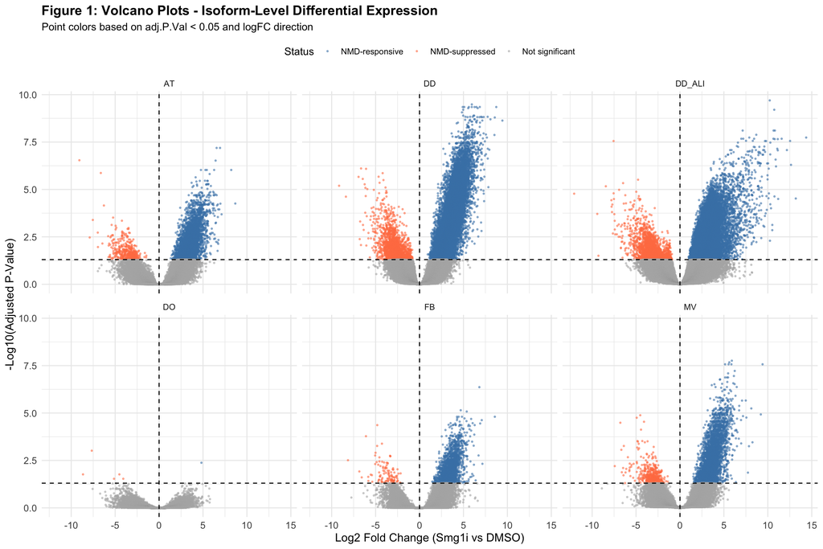

```r
volcano_data <- all_dge %>%
  mutate(
    neg_log10_p = -log10(adj.P.Val + 1e-300),  # Avoid log(0)
    significance = case_when(
      logFC > 0 & adj.P.Val < SIGNIFICANCE_THRESHOLD ~ "NMD-responsive",
      logFC < 0 & adj.P.Val < SIGNIFICANCE_THRESHOLD ~ "NMD-suppressed",
      TRUE ~ "Not significant"
    )
  )

ggplot(volcano_data, aes(x = logFC, y = neg_log10_p, color = significance)) +
  geom_point(alpha = 0.5, size = 0.5) +
  facet_wrap(~cell_type, ncol = 3) +
  scale_color_manual(values = c(
    "NMD-responsive" = "steelblue",
    "NMD-suppressed" = "coral",
    "Not significant" = "gray70"
  )) +
  geom_hline(yintercept = -log10(SIGNIFICANCE_THRESHOLD), linetype = "dashed", color = "black") +
  geom_vline(xintercept = 0, linetype = "dashed", color = "black") +
  labs(
    title = "Figure 1: Volcano Plots - Isoform-Level Differential Expression",
    subtitle = "Point colors based on adj.P.Val < 0.05 and logFC direction",
    x = "Log2 Fold Change (Smg1i vs DMSO)",
    y = "-Log10(Adjusted P-Value)",
    color = "Status"
  ) +
  theme_minimal() +
  theme(
    legend.position = "top",
    axis.text = element_text(size = 10),
    axis.title = element_text(size = 12),
    plot.title = element_text(size = 14, face = "bold")
  )
```

## 3.8 MA Plots

```r
cat("## MA Plots: Expression vs Fold Change\n\n")
```

```
## ## MA Plots: Expression vs Fold Change
```

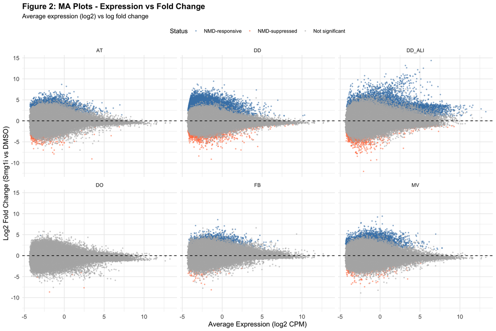

```r
# Use the same significance categories as volcano plot
ma_plot_data <- volcano_data

ggplot(ma_plot_data, aes(x = AveExpr, y = logFC, color = significance)) +
  geom_point(alpha = 0.5, size = 0.5) +
  facet_wrap(~cell_type, ncol = 3) +
  scale_color_manual(values = c(
    "NMD-responsive" = "steelblue",
    "NMD-suppressed" = "coral",
    "Not significant" = "gray70"
  )) +
  geom_hline(yintercept = 0, linetype = "dashed", color = "black") +
  labs(
    title = "Figure 2: MA Plots - Expression vs Fold Change",
    subtitle = "Average expression (log2) vs log fold change",
    x = "Average Expression (log2 CPM)",
    y = "Log2 Fold Change (Smg1i vs DMSO)",
    color = "Status"
  ) +
  theme_minimal() +
  theme(
    legend.position = "top",
    axis.text = element_text(size = 10),
    axis.title = element_text(size = 12),
    plot.title = element_text(size = 14, face = "bold")
  )
```

## 3.9 Heatmap of Top NMD-Responsive Transcripts

```r
cat("## Heatmap: Top 20 NMD-Responsive Transcripts per Cell Type\n\n")
```

```
## ## Heatmap: Top 20 NMD-Responsive Transcripts per Cell Type
```

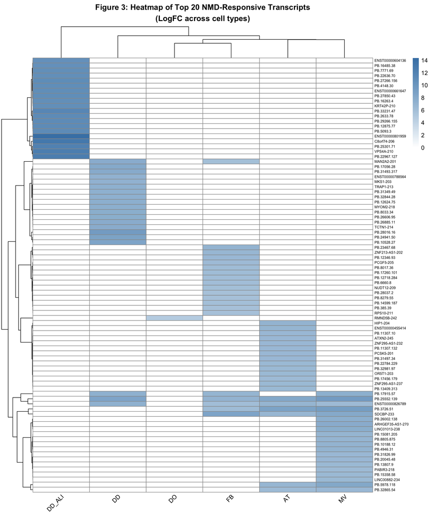

```r
# Select top 20 NMD-responsive per cell type by logFC
top_transcripts <- nmd_responsive %>%
  group_by(cell_type) %>%
  slice_max(order_by = logFC, n = 20, with_ties = FALSE) %>%
  ungroup()

# Prepare matrix (use gene names where available)
heatmap_data <- top_transcripts %>%
  mutate(display_name = ifelse(!is.na(transcript.gc) & transcript.gc != "",
                                transcript.gc,
                                transcript_id)) %>%
  select(cell_type, display_name, logFC) %>%
  pivot_wider(names_from = cell_type, values_from = logFC, values_fill = 0)

# Convert to matrix
heatmap_matrix <- heatmap_data %>%
  column_to_rownames("display_name") %>%
  as.matrix()

# Plot
pheatmap(heatmap_matrix,
         cluster_rows = TRUE,
         cluster_cols = TRUE,
         color = colorRampPalette(c("white", "steelblue"))(100),
         main = "Figure 3: Heatmap of Top 20 NMD-Responsive Transcripts\n(LogFC across cell types)",
         fontsize_row = 6,
         fontsize_col = 10,
         angle_col = 45)
```

## 3.10 LogFC Distribution

```r
cat("## LogFC Distribution for NMD-Responsive Transcripts\n\n")
```

```
## ## LogFC Distribution for NMD-Responsive Transcripts
```

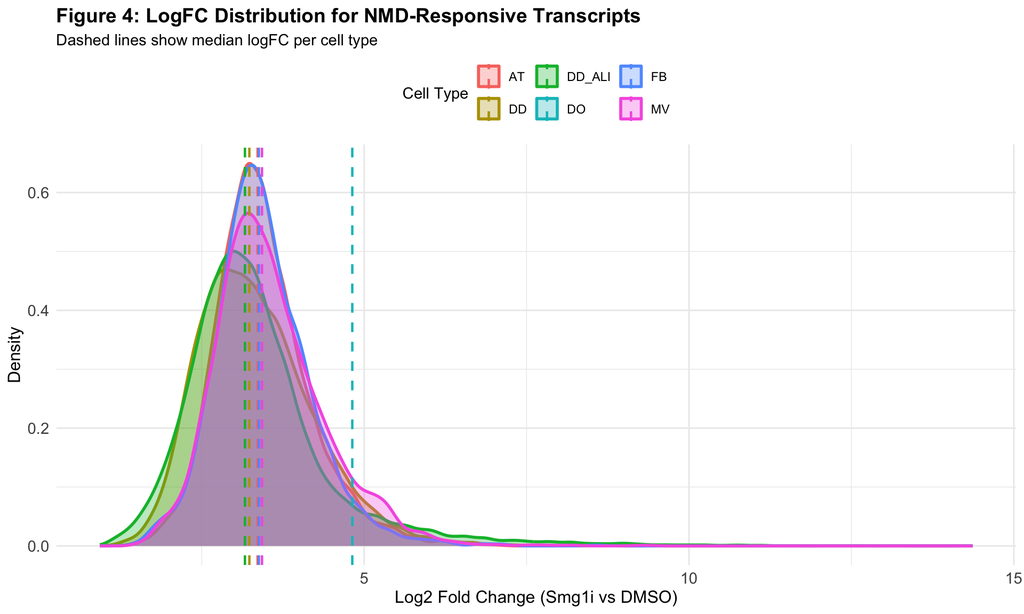

```r
# Calculate median logFC for each cell type
median_logfc <- nmd_responsive %>%
  group_by(cell_type) %>%
  summarize(median_logFC = median(logFC), .groups = "drop")

# Density plot
ggplot(nmd_responsive, aes(x = logFC, fill = cell_type, color = cell_type)) +
  geom_density(alpha = 0.3, linewidth = 1) +
  geom_vline(data = median_logfc, aes(xintercept = median_logFC, color = cell_type),
             linetype = "dashed", linewidth = 0.8) +
  labs(
    title = "Figure 4: LogFC Distribution for NMD-Responsive Transcripts",
    subtitle = "Dashed lines show median logFC per cell type",
    x = "Log2 Fold Change (Smg1i vs DMSO)",
    y = "Density",
    fill = "Cell Type",
    color = "Cell Type"
  ) +
  theme_minimal() +
  theme(
    legend.position = "top",
    axis.text = element_text(size = 11),
    axis.title = element_text(size = 12),
    plot.title = element_text(size = 14, face = "bold")
  )
```

# 4 Isoform-Level Cell-Type Overlap Analysis

## 4.1 Overlap of NMD-Responsive Transcripts Across Cell Types

For this analysis, we examine NMD-responsive **transcripts/isoforms** directly (logFC > 0, adj.P.Val < 0.05) to see which specific isoforms are responsive across multiple cell types.

```r
cat("## Identifying NMD-responsive transcripts across cell types\n\n")
```

```
## ## Identifying NMD-responsive transcripts across cell types
```

```r
# Count how many cell types each transcript is NMD-responsive in
transcript_celltype_counts <- nmd_responsive %>%
  select(cell_type, transcript_id, hgnc_id, gene_symbol) %>%
  group_by(transcript_id, hgnc_id, gene_symbol) %>%
  summarize(
    n_celltypes = n_distinct(cell_type),
    celltypes = paste(sort(unique(cell_type)), collapse = ", "),
    .groups = "drop"
  ) %>%
  arrange(desc(n_celltypes), transcript_id)

# Summary of overlap
isoform_overlap_summary <- transcript_celltype_counts %>%
  count(n_celltypes, name = "n_transcripts") %>%
  mutate(pct_transcripts = 100 * n_transcripts / sum(n_transcripts))

cat("**Isoform overlap summary:**\n\n")
```

```
## **Isoform overlap summary:**
```

```r
print(isoform_overlap_summary)
```

```
## # A tibble: 5 × 3
##   n_celltypes n_transcripts pct_transcripts
##         <int>         <int>           <dbl>
## 1           1         34947          82.1
## 2           2          4393          10.3
## 3           3          1829           4.30
## 4           4          1115           2.62
## 5           5           275           0.646
```

```r
cat("\n")
```

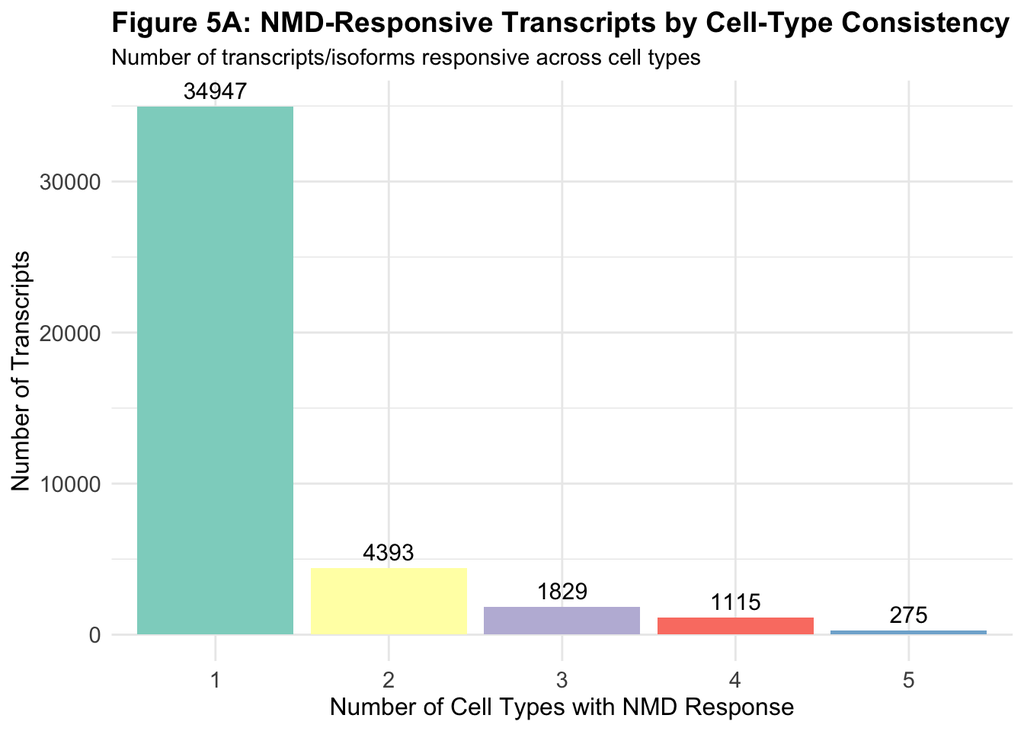

```r
# Visualization
ggplot(isoform_overlap_summary, aes(x = factor(n_celltypes), y = n_transcripts, fill = factor(n_celltypes))) +
  geom_col() +
  geom_text(aes(label = n_transcripts), vjust = -0.5, size = 4) +
  scale_fill_brewer(palette = "Set3") +
  labs(
    title = "Figure 5A: NMD-Responsive Transcripts by Cell-Type Consistency",
    subtitle = "Number of transcripts/isoforms responsive across cell types",
    x = "Number of Cell Types with NMD Response",
    y = "Number of Transcripts",
    fill = "Cell Types"
  ) +
  theme_minimal() +
  theme(
    legend.position = "none",
    axis.text = element_text(size = 11),
    axis.title = element_text(size = 12),
    plot.title = element_text(size = 14, face = "bold")
  )
```

```r
# Save overlap data
write_tsv(transcript_celltype_counts,
          file.path(OUTPUT_DIR, paste0("die_transcript_celltype_overlap_", DATE_STAMP, ".tsv")))
cat("\nSaved:", file.path(OUTPUT_DIR, paste0("die_transcript_celltype_overlap_", DATE_STAMP, ".tsv")), "\n\n")
```

```
##
## Saved: ../tmp/die_transcript_celltype_overlap_2026.1.15.tsv
```

## 4.2 NMD-Responsive Transcripts in Multiple Cell Types

```r
cat("## NMD-Responsive Transcripts Present in 2 or More Cell Types\n\n")
```

```
## ## NMD-Responsive Transcripts Present in 2 or More Cell Types
```

```r
# Filter for transcripts in 2+ cell types
multi_celltype_transcripts <- transcript_celltype_counts %>%
  filter(n_celltypes >= 2) %>%
  arrange(desc(n_celltypes))

cat("Transcripts present in 2+ cell types:", nrow(multi_celltype_transcripts), "\n\n")
```

```
## Transcripts present in 2+ cell types: 7612
```

```r
if (nrow(multi_celltype_transcripts) > 0) {
  # Save to file first
  output_multi_celltype <- file.path(OUTPUT_DIR, paste0("die_multi_celltype_transcripts_", DATE_STAMP, ".tsv"))

  # Get logFC values for these transcripts across specified cell types
  # Include only: AT, DD, FB, MV (exclude DO and DD_ALI)
  selected_celltypes <- c("AT", "DD", "FB", "MV")

  # Get logFC values for transcripts that are NMD-responsive in at least one of the selected cell types
  multi_celltype_wide <- nmd_responsive %>%
    filter(cell_type %in% selected_celltypes) %>%
    semi_join(multi_celltype_transcripts, by = "transcript_id") %>%
    select(transcript_id, gene_symbol, cell_type, logFC) %>%
    # Create display name prioritizing gene symbol
    mutate(transcript_display = ifelse(!is.na(gene_symbol) & gene_symbol != "",
                                       paste0(gene_symbol, " (", transcript_id, ")"),
                                       transcript_id)) %>%
    select(transcript_id, transcript_display, cell_type, logFC) %>%
    pivot_wider(
      id_cols = c(transcript_id, transcript_display),
      names_from = cell_type,
      values_from = logFC,
      values_fill = NA,
      names_prefix = "logFC_"
    ) %>%
    # Add n_celltypes column by joining with the counts
    left_join(
      transcript_celltype_counts %>% select(transcript_id, n_celltypes),
      by = "transcript_id"
    ) %>%
    # Remove transcript_id and reorder columns
    select(transcript_display, n_celltypes, starts_with("logFC_")) %>%
    # Only keep transcripts that have at least one logFC value
    filter(if_any(starts_with("logFC_"), ~!is.na(.))) %>%
    arrange(desc(n_celltypes))

  write_tsv(multi_celltype_wide, output_multi_celltype)
  cat("Saved:", output_multi_celltype, "\n\n")

  # Display in interactive table
  cat("**Table. NMD-Responsive Transcripts in 2+ Cell Types**\n\n")
  cat("Column definitions:\n")
  cat("- **transcript_display**: Transcript identifier with gene symbol if available\n")
  cat("- **n_celltypes**: Number of cell types where transcript is NMD-responsive\n")
  cat("- **logFC_AT**, **logFC_DD**, **logFC_FB**, **logFC_MV**: Log2 fold change in each cell type (NA if not responsive)\n\n")

  # Determine which logFC columns actually exist in the data
  logfc_cols <- colnames(multi_celltype_wide)[grepl("^logFC_", colnames(multi_celltype_wide))]

  # This must be the last expression in the block to render properly
  datatable(
    multi_celltype_wide,
    options = list(
      pageLength = 25,
      scrollX = TRUE
    ),
    caption = "NMD-responsive transcripts present in 2 or more cell types"
  ) %>%
    formatRound(columns = logfc_cols, digits = 2)
}
```

```
## Saved: ../tmp/die_multi_celltype_transcripts_2026.1.15.tsv
##
## **Table. NMD-Responsive Transcripts in 2+ Cell Types**
##
## Column definitions:
## - **transcript_display**: Transcript identifier with gene symbol if available
## - **n_celltypes**: Number of cell types where transcript is NMD-responsive
## - **logFC_AT**, **logFC_DD**, **logFC_FB**, **logFC_MV**: Log2 fold change in each cell type (NA if not responsive)
```

|  | transcript_display | n_celltypes | logFC_AT | logFC_DD | logFC_FB | logFC_MV |
| --- | --- | --- | --- | --- | --- | --- |
| 1 | DENND1B (PB.2650.23) | 5 | 4.636 | 5.616 | 4.289 | 5.142 |
| 2 | GGCX (ENST00000896462.1) | 5 | 3.701 | 4.373 | 3.538 | 4.57 |
| 3 | ENSG00000290065 (ENST00000702745.2) | 5 | 5.395 | 4.396 | 5.123 | 5.705 |
| 4 | ARGLU1 (PB.9018.11) | 5 | 3.803 | 4.918 | 3.589 | 5.136 |
| 5 | CYP20A1 (PB.18365.75) | 5 | 4.671 | 4.05 | 3.782 | 4.646 |
| 6 | CLIP1 (PB.8172.360) | 5 | 3.376 | 3.757 | 3.308 | 4.047 |
| 7 | KPNA6 (PB.634.11) | 5 | 4.95 | 5.029 | 3.998 | 5.821 |
| 8 | FGFR2 (PB.4700.12) | 5 | 5.682 | 4.541 | 4.102 | 5.789 |
| 9 | MYL12B (PB.14106.10) | 5 | 4.282 | 4.544 | 4.172 | 6.137 |
| 10 | ENSG00000290549 (ENST00000825830.1) | 5 | 3.938 | 4.731 | 3.139 | 3.987 |

[output cut: 7602 more lines]

## 4.3 Core NMD Target Transcripts

Transcripts responsive in **≥4 cell types** are considered core NMD target isoforms.

```r
cat("## Core NMD Target Transcripts (≥4 cell types)\n\n")
```

```
## ## Core NMD Target Transcripts (≥4 cell types)
```

```r
# Identify core transcripts
core_transcripts <- transcript_celltype_counts %>%
  filter(n_celltypes >= 4) %>%
  arrange(desc(n_celltypes), transcript_id)

cat("Core NMD target transcripts (≥4 cell types):", nrow(core_transcripts), "transcripts\n\n")
```

```
## Core NMD target transcripts (≥4 cell types): 1390 transcripts
```

```r
if (nrow(core_transcripts) > 0) {
  cat("**Top 50 Core NMD Target Transcripts**\n\n")

  datatable(
    core_transcripts %>% head(50),
    options = list(pageLength = 10, scrollX = TRUE),
    caption = "Core NMD target transcripts responsive in ≥4 cell types"
  )

  # Save core transcripts
  write_tsv(core_transcripts,
            file.path(OUTPUT_DIR, paste0("die_core_nmd_transcripts_", DATE_STAMP, ".tsv")))
  cat("\nSaved:", file.path(OUTPUT_DIR, paste0("die_core_nmd_transcripts_", DATE_STAMP, ".tsv")), "\n\n")

  # Get detailed DGE info for core transcripts
  core_transcript_details <- nmd_responsive %>%
    filter(transcript_id %in% core_transcripts$transcript_id) %>%
    select(cell_type, transcript_id, hgnc_id, gene_symbol, transcript.gc, biotype,
           logFC, adj.P.Val, AveExpr) %>%
    arrange(transcript_id, cell_type)

  write_tsv(core_transcript_details,
            file.path(OUTPUT_DIR, paste0("die_core_transcript_details_", DATE_STAMP, ".tsv")))
  cat("Saved transcript details:",
      file.path(OUTPUT_DIR, paste0("die_core_transcript_details_", DATE_STAMP, ".tsv")), "\n\n")
} else {
  cat("No transcripts found in ≥4 cell types\n\n")
}
```

[output not shown]

```
## **Top 50 Core NMD Target Transcripts**
##
##
## Saved: ../tmp/die_core_nmd_transcripts_2026.1.15.tsv
##
## Saved transcript details: ../tmp/die_core_transcript_details_2026.1.15.tsv
```

## 4.4 Cell-Type Specific NMD Transcripts

Transcripts responsive in **only 1 cell type** are considered cell-type specific.

```r
cat("## Cell-Type Specific NMD Transcripts (1 cell type only)\n\n")
```

```
## ## Cell-Type Specific NMD Transcripts (1 cell type only)
```

```r
# Identify cell-type specific transcripts
celltype_specific_transcripts <- transcript_celltype_counts %>%
  filter(n_celltypes == 1) %>%
  # Join back to get cell type and logFC info
  left_join(
    nmd_responsive %>%
      select(transcript_id, cell_type, logFC, adj.P.Val, biotype),
    by = "transcript_id"
  ) %>%
  arrange(cell_type, desc(logFC))

cat("Cell-type specific transcripts:", nrow(celltype_specific_transcripts), "transcripts\n\n")
```

```
## Cell-type specific transcripts: 34947 transcripts
```

```r
# Summary by cell type
specific_transcript_summary <- celltype_specific_transcripts %>%
  group_by(cell_type) %>%
  summarize(
    n_transcripts = n(),
    mean_logFC = mean(logFC),
    .groups = "drop"
  )

cat("**Cell-type specific NMD transcripts by cell type:**\n\n")
```

```
## **Cell-type specific NMD transcripts by cell type:**
```

```r
print(specific_transcript_summary)
```

```
## # A tibble: 6 × 3
##   cell_type n_transcripts mean_logFC
##   <chr>             <int>      <dbl>
## 1 AT                 1057       3.51
## 2 DD                19037       3.29
## 3 DD_ALI            14098       3.37
## 4 DO                    1       4.82
## 5 FB                  243       3.51
## 6 MV                  511       3.36
```

```r
cat("\n")
```

```r
if (nrow(celltype_specific_transcripts) > 0) {
  # Display top 10 per cell type
  cat("**Top 10 cell-type specific transcripts per cell type:**\n\n")

  for (ct in unique(all_dge$cell_type)) {
    ct_specific <- celltype_specific_transcripts %>%
      filter(cell_type == ct) %>%
      select(transcript_id, gene_symbol, biotype, logFC, adj.P.Val) %>%
      head(10)

    if (nrow(ct_specific) > 0) {
      cat("**", ct, "** (",
          nrow(celltype_specific_transcripts %>% filter(cell_type == ct)), " total)\n")
      print(knitr::kable(ct_specific, digits = 3, row.names = FALSE))
      cat("\n")
    }
  }

  # Save cell-type specific transcripts
  write_tsv(celltype_specific_transcripts,
            file.path(OUTPUT_DIR, paste0("die_celltype_specific_transcripts_", DATE_STAMP, ".tsv")))
  cat("\nSaved:",
      file.path(OUTPUT_DIR, paste0("die_celltype_specific_transcripts_", DATE_STAMP, ".tsv")), "\n\n")
}
```

```
## **Top 10 cell-type specific transcripts per cell type:**
##
## ** AT ** ( 1057  total)
##
##
## |transcript_id     |gene_symbol                  |biotype                        | logFC| adj.P.Val|
## |:-----------------|:----------------------------|:------------------------------|-----:|---------:|
## |PB.11307.10       |NPRL3                        |NA                             | 6.734|     0.007|
## |PB.11307.132      |NPRL3                        |NA                             | 6.690|     0.000|
## |ENST00000376752.9 |PCSK5                        |protein_coding                 | 6.662|     0.017|
## |ENST00000845106.1 |ZNF295-AS1                   |lncRNA                         | 6.501|     0.006|
## |ENST00000367918.1 |SLC18B1                      |protein_coding_CDS_not_defined | 6.375|     0.004|
## |PB.25384.100      |KIF2A                        |NA                             | 6.259|     0.004|
## |PB.19729.147      |CDH26                        |NA                             | 5.999|     0.001|
## |ENST00000742597.1 |SNHG1                        |lncRNA                         | 5.903|     0.000|
## |ENST00000467971.5 |SEPTIN2                      |retained_intron                | 5.876|     0.026|
## |PB.12840.476      |novelGene_ENSG00000263624_AS |NA                             | 5.793|     0.022|
##
## ** DD ** ( 19037  total)
##
##
## |transcript_id     |gene_symbol     |biotype                 | logFC| adj.P.Val|
## |:-----------------|:---------------|:-----------------------|-----:|---------:|
## |PB.24941.50       |LPCAT1          |NA                      | 8.736|         0|
## |PB.10528.27       |DUOXA1          |NA                      | 8.526|         0|
## |PB.26606.95       |PHYKPL          |NA                      | 7.755|         0|
## |PB.12624.75       |KIF1C           |NA                      | 7.567|         0|
## |ENST00000887733.1 |MYOM2           |protein_coding          | 7.559|         0|
## |ENST00000575707.5 |TRAP1           |nonsense_mediated_decay | 7.382|         0|
## |PB.32844.28       |HSDL2           |NA                      | 7.351|         0|
## |ENST00000788564.1 |ENSG00000302653 |lncRNA                  | 7.309|         0|
## |PB.12624.98       |KIF1C           |NA                      | 7.293|         0|
## |ENST00000880780.1 |ZZZ3            |protein_coding          | 7.281|         0|
##
## ** DD_ALI ** ( 14098  total)
##
##
## |transcript_id     |gene_symbol     |biotype                 |  logFC| adj.P.Val|
## |:-----------------|:---------------|:-----------------------|------:|---------:|
## |ENST00000801959.1 |ENSG00000304304 |lncRNA                  | 14.365|         0|
```

[output cut: 36 more lines]

```
## |transcript_id     |gene_symbol      |biotype                            | logFC| adj.P.Val|
## |:-----------------|:----------------|:----------------------------------|-----:|---------:|
## |ENST00000669461.1 |LINC01013        |lncRNA                             | 7.735|     0.014|
## |PB.12122.106      |SNTB2            |NA                                 | 6.365|     0.044|
## |PB.23733.16       |SGCB             |NA                                 | 5.905|     0.000|
## |PB.19518.7        |novelGene_124889 |NA                                 | 5.480|     0.024|
## |PB.16084.405      |ZNF28            |NA                                 | 5.378|     0.003|
## |PB.12347.103      |DNAAF1           |NA                                 | 5.308|     0.006|
## |PB.22100.63       |ALCAM            |NA                                 | 5.299|     0.021|
## |ENST00000455058.1 |CEACAM22P        |transcribed_unprocessed_pseudogene | 5.277|     0.005|
## |PB.23732.7        |DCUN1D4          |NA                                 | 5.246|     0.000|
## |ENST00000439057.6 |KDM4A-AS1        |lncRNA                             | 5.227|     0.003|
##
##
## Saved: ../tmp/die_celltype_specific_transcripts_2026.1.15.tsv
```

## 4.5 Isoform-Level Interpretation

```r
cat("## Isoform-Level Overlap Interpretation\n\n")
```

```
## ## Isoform-Level Overlap Interpretation
```

```r
total_transcripts <- n_distinct(nmd_responsive$transcript_id)
transcripts_in_all <- sum(transcript_celltype_counts$n_celltypes == 6)
transcripts_in_1 <- sum(transcript_celltype_counts$n_celltypes == 1)

cat("**Summary:**\n")
```

```
## **Summary:**
```

```r
cat("- Total unique NMD-responsive transcripts:", total_transcripts, "\n")
```

```
## - Total unique NMD-responsive transcripts: 42559
```

```r
cat("- Transcripts in all 6 cell types:", transcripts_in_all,
    "(", round(100 * transcripts_in_all / total_transcripts, 1), "%)\n")
```

```
## - Transcripts in all 6 cell types: 0 ( 0 %)
```

```r
cat("- Transcripts in only 1 cell type:", transcripts_in_1,
    "(", round(100 * transcripts_in_1 / total_transcripts, 1), "%)\n\n")
```

```
## - Transcripts in only 1 cell type: 34947 ( 82.1 %)
```

```r
cat("**Biological Interpretation:**\n")
```

```
## **Biological Interpretation:**
```

```r
cat("- **Core NMD isoforms** (responsive across multiple cell types) represent\n")
```

```
## - **Core NMD isoforms** (responsive across multiple cell types) represent
```

```r
cat("  specific transcript variants that are consistently targeted by NMD\n")
```

```
##   specific transcript variants that are consistently targeted by NMD
```

```r
cat("- **Cell-type-specific isoforms** may reflect:\n")
```

```
## - **Cell-type-specific isoforms** may reflect:
```

```r
cat("  - Alternative splicing patterns unique to specific cell types\n")
```

```
##   - Alternative splicing patterns unique to specific cell types
```

```r
cat("  - Cell-type-specific expression of certain isoforms\n")
```

```
##   - Cell-type-specific expression of certain isoforms
```

```r
cat("  - Differential NMD sensitivity of isoforms across cell contexts\n\n")
```

```
##   - Differential NMD sensitivity of isoforms across cell contexts
```

# 5 Gene-Level Cell-Type Overlap Analysis

## 5.1 Overlap of NMD-Responsive Genes Across Cell Types

For this analysis, we aggregate NMD-responsive transcripts to the **gene level**. A gene is considered “NMD-responsive” in a cell type if it has **at least one transcript** with logFC > 0 and adj.P.Val < 0.05.

```r
cat("## Identifying genes with NMD-responsive transcripts\n\n")
```

```
## ## Identifying genes with NMD-responsive transcripts
```

```r
# Extract unique genes with NMD-responsive transcripts per cell type
nmd_responsive_genes <- nmd_responsive %>%
  select(cell_type, hgnc_id, gene_symbol) %>%
  distinct() %>%
  filter(!is.na(hgnc_id), hgnc_id != "")

cat("Genes with NMD-responsive transcripts:\n")
```

```
## Genes with NMD-responsive transcripts:
```

```r
gene_counts <- nmd_responsive_genes %>%
  group_by(cell_type) %>%
  summarize(n_genes = n_distinct(hgnc_id), .groups = "drop")
print(gene_counts)
```

```
## # A tibble: 6 × 2
##   cell_type n_genes
##   <chr>       <int>
## 1 AT           4337
## 2 DD          13701
## 3 DD_ALI       8239
## 4 DO              1
## 5 FB           1825
## 6 MV           3361
```

```r
cat("\n")
```

```r
# Count how many cell types each gene is NMD-responsive in
gene_celltype_counts <- nmd_responsive_genes %>%
  group_by(hgnc_id, gene_symbol) %>%
  summarize(
    n_celltypes = n_distinct(cell_type),
    celltypes = paste(sort(unique(cell_type)), collapse = ", "),
    .groups = "drop"
  ) %>%
  arrange(desc(n_celltypes), gene_symbol)

# Summary of overlap
overlap_summary <- gene_celltype_counts %>%
  count(n_celltypes, name = "n_genes") %>%
  mutate(pct_genes = 100 * n_genes / sum(n_genes))

cat("**Gene overlap summary:**\n\n")
```

```
## **Gene overlap summary:**
```

```r
print(overlap_summary)
```

```
## # A tibble: 5 × 3
##   n_celltypes n_genes pct_genes
##         <int>   <int>     <dbl>
## 1           1   12733     65.7
## 2           2    3403     17.6
## 3           3    1609      8.30
## 4           4    1067      5.51
## 5           5     566      2.92
```

```r
cat("\n")
```

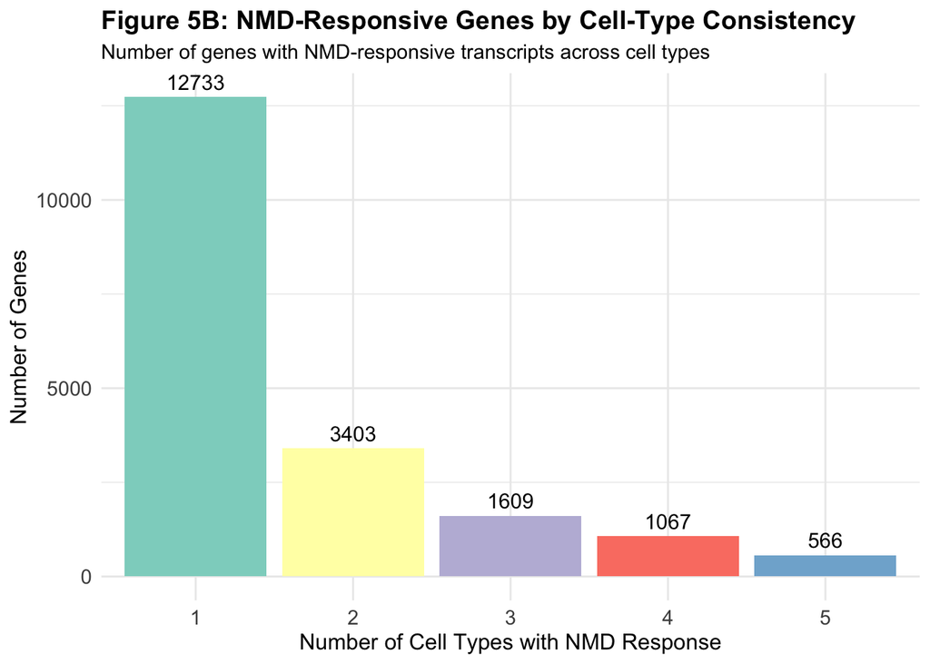

```r
# Visualization
ggplot(overlap_summary, aes(x = factor(n_celltypes), y = n_genes, fill = factor(n_celltypes))) +
  geom_col() +
  geom_text(aes(label = n_genes), vjust = -0.5, size = 4) +
  scale_fill_brewer(palette = "Set3") +
  labs(
    title = "Figure 5B: NMD-Responsive Genes by Cell-Type Consistency",
    subtitle = "Number of genes with NMD-responsive transcripts across cell types",
    x = "Number of Cell Types with NMD Response",
    y = "Number of Genes",
    fill = "Cell Types"
  ) +
  theme_minimal() +
  theme(
    legend.position = "none",
    axis.text = element_text(size = 11),
    axis.title = element_text(size = 12),
    plot.title = element_text(size = 14, face = "bold")
  )
```

```r
# Save overlap data
write_tsv(gene_celltype_counts,
          file.path(OUTPUT_DIR, paste0("die_gene_celltype_overlap_", DATE_STAMP, ".tsv")))
cat("\nSaved:", file.path(OUTPUT_DIR, paste0("die_gene_celltype_overlap_", DATE_STAMP, ".tsv")), "\n\n")
```

```
##
## Saved: ../tmp/die_gene_celltype_overlap_2026.1.15.tsv
```

## 5.2 Core NMD Target Genes

Genes with NMD-responsive transcripts in **≥4 cell types** are considered “core” NMD targets.

```r
cat("## Core NMD Target Genes (≥4 cell types)\n\n")
```

```
## ## Core NMD Target Genes (≥4 cell types)
```

```r
# Identify core targets
core_genes <- gene_celltype_counts %>%
  filter(n_celltypes >= 4) %>%
  arrange(desc(n_celltypes), gene_symbol)

cat("Core NMD target genes (≥4 cell types):", nrow(core_genes), "genes\n\n")
```

```
## Core NMD target genes (≥4 cell types): 1633 genes
```

```r
if (nrow(core_genes) > 0) {
  cat("**Table: Top 50 Core NMD Target Genes**\n\n")

  datatable(
    core_genes %>% head(50),
    options = list(pageLength = 10, scrollX = TRUE),
    caption = "Core NMD target genes with NMD-responsive transcripts in ≥4 cell types"
  )

  # Save core genes
  write_tsv(core_genes,
            file.path(OUTPUT_DIR, paste0("die_core_nmd_genes_", DATE_STAMP, ".tsv")))
  cat("\nSaved:", file.path(OUTPUT_DIR, paste0("die_core_nmd_genes_", DATE_STAMP, ".tsv")), "\n\n")

  # Get transcript-level details for core genes
  core_gene_transcripts <- nmd_responsive %>%
    filter(hgnc_id %in% core_genes$hgnc_id) %>%
    select(cell_type, hgnc_id, gene_symbol, transcript_id, logFC, adj.P.Val, AveExpr) %>%
    arrange(hgnc_id, cell_type, desc(logFC))

  write_tsv(core_gene_transcripts,
            file.path(OUTPUT_DIR, paste0("die_core_gene_transcripts_", DATE_STAMP, ".tsv")))
  cat("Saved transcript details:",
      file.path(OUTPUT_DIR, paste0("die_core_gene_transcripts_", DATE_STAMP, ".tsv")), "\n\n")
} else {
  cat("No genes found in ≥4 cell types\n\n")
}
```

```
## **Table: Top 50 Core NMD Target Genes**
##
##
## Saved: ../tmp/die_core_nmd_genes_2026.1.15.tsv
##
## Saved transcript details: ../tmp/die_core_gene_transcripts_2026.1.15.tsv
```

## 5.3 Cell-Type Specific NMD Genes

Genes with NMD-responsive transcripts in **only 1 cell type** are considered cell-type specific.

```r
cat("## Cell-Type Specific NMD Genes (1 cell type only)\n\n")
```

```
## ## Cell-Type Specific NMD Genes (1 cell type only)
```

```r
# Identify cell-type specific genes
celltype_specific_genes <- gene_celltype_counts %>%
  filter(n_celltypes == 1) %>%
  # Join back to get cell type info
  left_join(
    nmd_responsive_genes %>% select(hgnc_id, cell_type),
    by = "hgnc_id"
  ) %>%
  arrange(cell_type, gene_symbol)

cat("Cell-type specific genes:", nrow(celltype_specific_genes), "genes\n\n")
```

```
## Cell-type specific genes: 12733 genes
```

```r
# Summary by cell type
specific_summary <- celltype_specific_genes %>%
  group_by(cell_type) %>%
  summarize(n_genes = n(), .groups = "drop")

cat("**Cell-type specific NMD genes by cell type:**\n\n")
```

```
## **Cell-type specific NMD genes by cell type:**
```

```r
print(specific_summary)
```

```
## # A tibble: 6 × 2
##   cell_type n_genes
##   <chr>       <int>
## 1 AT            410
## 2 DD           7288
## 3 DD_ALI       4769
## 4 DO              1
## 5 FB             76
## 6 MV            189
```

```r
cat("\n")
```

```r
if (nrow(celltype_specific_genes) > 0) {
  # Display top 20 per cell type
  cat("**Top 20 cell-type specific genes per cell type:**\n\n")

  for (ct in unique(all_dge$cell_type)) {
    ct_specific <- celltype_specific_genes %>%
      filter(cell_type == ct) %>%
      select(gene_symbol, hgnc_id) %>%
      head(20)

    if (nrow(ct_specific) > 0) {
      cat("**", ct, "** (", nrow(celltype_specific_genes %>% filter(cell_type == ct)), " total)\n")
      print(knitr::kable(ct_specific, row.names = FALSE))
      cat("\n")
    }
  }

  # Save cell-type specific genes
  write_tsv(celltype_specific_genes,
            file.path(OUTPUT_DIR, paste0("die_celltype_specific_genes_", DATE_STAMP, ".tsv")))
  cat("\nSaved:",
      file.path(OUTPUT_DIR, paste0("die_celltype_specific_genes_", DATE_STAMP, ".tsv")), "\n\n")
}
```

```
## **Top 20 cell-type specific genes per cell type:**
##
## ** AT ** ( 410  total)
##
##
## |gene_symbol |hgnc_id         |
## |:-----------|:---------------|
## |AAR2        |ENSG00000131043 |
## |ABCA6       |ENSG00000154262 |
## |ABCC13      |ABCC13          |
## |ACAD8       |ENSG00000151498 |
## |ACTG1P15    |ACTG1P15        |
## |ADARB1      |ENSG00000197381 |
## |AGFG1       |ENSG00000173744 |
## |AHCYL2      |ENSG00000158467 |
## |ANK3        |ANK3            |
## |AREG        |AREG            |
## |ARHGEF38    |ARHGEF38        |
## |ARLNC1      |ARLNC1          |
## |ARMCX1      |ARMCX1          |
## |ARPP19      |ARPP19          |
## |ATG2B       |ENSG00000066739 |
## |ATP6V0E1    |ENSG00000113732 |
## |BAG5        |ENSG00000166170 |
## |BBOX1       |BBOX1           |
## |BOLA3-DT    |ENSG00000225439 |
## |C4orf33     |C4orf33         |
##
## ** DD ** ( 7288  total)
##
##
## |gene_symbol |hgnc_id         |
## |:-----------|:---------------|
## |A1BG-AS1    |A1BG-AS1        |
## |AAMDC       |AAMDC           |
## |AAMP        |AAMP            |
## |AARS1       |AARS1           |
## |AARS1       |ENSG00000090861 |
## |AARSD1      |ENSG00000266967 |
## |AASDH       |AASDH           |
```

[output cut: 86 more lines]

```
## |BCR         |ENSG00000186716 |
## |BTG2-DT     |BTG2-DT         |
## |C11orf16    |C11orf16        |
## |C19orf12    |C19orf12        |
## |CAPZA1      |ENSG00000116489 |
## |CASC2       |ENSG00000177640 |
## |CCDC174     |CCDC174         |
## |CCDC26      |CCDC26          |
## |CCT6A       |ENSG00000146731 |
## |CEACAM22P   |CEACAM22P       |
## |COMMD1      |COMMD1          |
## |COP1        |COP1            |
##
##
## Saved: ../tmp/die_celltype_specific_genes_2026.1.15.tsv
```

## 5.4 Interpretation

```r
cat("## Cell-Type Overlap Interpretation\n\n")
```

```
## ## Cell-Type Overlap Interpretation
```

```r
total_genes <- n_distinct(nmd_responsive_genes$hgnc_id)
genes_in_all <- sum(gene_celltype_counts$n_celltypes == 6)
genes_in_1 <- sum(gene_celltype_counts$n_celltypes == 1)

cat("**Summary:**\n")
```

```
## **Summary:**
```

```r
cat("- Total unique genes with NMD-responsive transcripts:", total_genes, "\n")
```

```
## - Total unique genes with NMD-responsive transcripts: 19378
```

```r
cat("- Genes in all 6 cell types:", genes_in_all,
    "(", round(100 * genes_in_all / total_genes, 1), "%)\n")
```

```
## - Genes in all 6 cell types: 0 ( 0 %)
```

```r
cat("- Genes in only 1 cell type:", genes_in_1,
    "(", round(100 * genes_in_1 / total_genes, 1), "%)\n\n")
```

```
## - Genes in only 1 cell type: 12733 ( 65.7 %)
```

```r
cat("**Biological Interpretation:**\n")
```

```
## **Biological Interpretation:**
```

```r
cat("- **Core NMD targets** (present in multiple cell types) likely represent\n")
```

```
## - **Core NMD targets** (present in multiple cell types) likely represent
```

```r
cat("  constitutively NMD-regulated genes with shared biological functions\n")
```

```
##   constitutively NMD-regulated genes with shared biological functions
```

```r
cat("- **Cell-type-specific genes** may reflect tissue-specific NMD regulation\n")
```

```
## - **Cell-type-specific genes** may reflect tissue-specific NMD regulation
```

```r
cat("  or cell-type-specific expression patterns\n\n")
```

```
##   or cell-type-specific expression patterns
```

# 6 PART 2: Functional Enrichment Analysis

## 6.1 Load Additional Data for Enrichment

### 6.1.1 Load Gene-Level DGE

```r
cat("## Loading Gene-Level DGE from shortread_dge/\n\n")
```

```
## ## Loading Gene-Level DGE from shortread_dge/
```

```r
# Note: Gene symbols were already loaded in the add-gene-symbols chunk
# This chunk loads full gene-level DGE data for enrichment analysis

# Load all gene-level DGE files
gene_dge_files <- list.files(INPUT_GENE_DGE_DIR,
                              pattern = "^nmd_sr_dge_.*_2026\\.1\\.2\\.csv$",
                              full.names = TRUE)

cat("Found", length(gene_dge_files), "gene-level DGE files:\n")
```

```
## Found 6 gene-level DGE files:
```

```r
print(basename(gene_dge_files))
```

```
## [1] "nmd_sr_dge_at2_2026.1.2.csv"   "nmd_sr_dge_dd_2026.1.2.csv"
## [3] "nmd_sr_dge_ddali_2026.1.2.csv" "nmd_sr_dge_doali_2026.1.2.csv"
## [5] "nmd_sr_dge_fb_2026.1.2.csv"    "nmd_sr_dge_mv_2026.1.2.csv"
```

```r
cat("\n")
```

```r
gene_dge <- map_df(gene_dge_files, ~{
  df <- read_csv(.x, show_col_types = FALSE)

  # Extract cell type from filename
  basename_file <- basename(.x)
  parts <- str_split(basename_file, "_")[[1]]
  celltype <- parts[4]  # "at2", "dd", "ddali", etc.

  df$cell_type_file <- celltype
  df
})

# Map to display names
gene_dge$cell_type <- CELLTYPE_MAP[gene_dge$cell_type_file]
gene_dge <- gene_dge %>% filter(!is.na(cell_type))

cat("Combined gene-level DGE data:\n")
```

```
## Combined gene-level DGE data:
```

```r
cat("- Total rows:", nrow(gene_dge), "\n")
```

```
## - Total rows: 124380
```

```r
cat("- Genes per cell type:", nrow(gene_dge) / length(unique(gene_dge$cell_type)), "\n")
```

```
## - Genes per cell type: 20730
```

```r
cat("- Cell types:", paste(unique(gene_dge$cell_type), collapse = ", "), "\n")
```

```
## - Cell types: AT, DD, DD_ALI, DO, FB, MV
```

```r
cat("\n")
```

### 6.1.2 Calculate Isoform Proportions for Dominance

```r
cat("## Calculating Isoform Proportions to Determine Dominance\n\n")
```

```
## ## Calculating Isoform Proportions to Determine Dominance
```

```r
# Load DGEList
dge_isoform <- readRDS(INPUT_DGELIST)
cat("Loaded DGEList:", nrow(dge_isoform), "transcripts x", ncol(dge_isoform), "samples\n\n")
```

```
## Loaded DGEList: 299989 transcripts x 38 samples
```

```r
# Extract normalized CPM
cpm_normalized <- cpm(dge_isoform, normalized = TRUE, log = FALSE)

# Convert to long format with sample metadata
cpm_long <- as.data.frame(cpm_normalized) %>%
  mutate(transcript_id = dge_isoform$genes$txid) %>%
  pivot_longer(cols = -transcript_id,
               names_to = "bamid",
               values_to = "cpm") %>%
  left_join(dge_isoform$samples %>%
              select(bamid, sample, treatment, ct),
            by = "bamid") %>%
  rename(cell_type = ct)

# Create unified hgnc_id column in DGEList (prefer .gc, fallback to .sq)
dge_isoform$genes$hgnc_id <- ifelse(is.na(dge_isoform$genes$hgnc_id.gc),
                                     dge_isoform$genes$hgnc_id.sq,
                                     dge_isoform$genes$hgnc_id.gc)

# Add gene information
cpm_long <- cpm_long %>%
  left_join(dge_isoform$genes %>% select(txid, hgnc_id),
            by = c("transcript_id" = "txid")) %>%
  rename(gene_id = hgnc_id)

# Note: DGEList already has cell types in final format (DD_ALI, DD, DO, AT, MV, FB)
# No need to map cell types here

# # Calculate isoform proportions
# all_proportions <- cpm_long %>%
#   group_by(cell_type, treatment, sample, gene_id) %>%
#   mutate(
#     gene_total_cpm = sum(cpm),
#     isoform_proportion = ifelse(gene_total_cpm > 0, cpm / gene_total_cpm, 0),
#     n_isoforms = n()
#   ) %>%
#   ungroup()
#
# saveRDS(all_proportions,file="/Users/petecastaldi/claude_projects/nmd/all_proportions_2026.1.15.rds")
all_proportions<-readRDS("/Users/petecastaldi/claude_projects/nmd/all_proportions_2026.1.15.rds")

cat("Calculated proportions for", nrow(all_proportions), "transcript-sample combinations\n\n")
```

```
## Calculated proportions for 11399582 transcript-sample combinations
```

```r
# # Determine dominant isoforms (>50% in at least one sample)
# dominant_isoforms <- all_proportions %>%
#   group_by(cell_type, gene_id, transcript_id, treatment) %>%
#   summarize(mean_prop = mean(isoform_proportion), .groups = "drop") %>%
#   mutate(is_dominant = mean_prop > 0.5) %>%
#   group_by(cell_type, transcript_id) %>%
#   summarize(
#     dominant_in_dmso = any(is_dominant[treatment == "DMSO"], na.rm = TRUE),
#     dominant_in_smg1i = any(is_dominant[treatment == "Smg1i"], na.rm = TRUE),
#     dominant_in_either = dominant_in_dmso | dominant_in_smg1i,
#     .groups = "drop"
#   )
#
# saveRDS(dominant_isoforms,file="/Users/petecastaldi/claude_projects/nmd/dominant_isoforms_2026.1.15.rds")
dominant_isoforms<-readRDS("/Users/petecastaldi/claude_projects/nmd/dominant_isoforms_2026.1.15.rds")

cat("Identified dominant isoforms\n")
```

```
## Identified dominant isoforms
```

```r
cat("- Total isoforms analyzed:", nrow(dominant_isoforms), "\n")
```

```
## - Total isoforms analyzed: 1799934
```

```r
cat("- Dominant in DMSO:", sum(dominant_isoforms$dominant_in_dmso), "\n")
```

```
## - Dominant in DMSO: 243777
```

```r
cat("- Dominant in Smg1i:", sum(dominant_isoforms$dominant_in_smg1i), "\n")
```

```
## - Dominant in Smg1i: 260194
```

```r
cat("- Dominant in either:", sum(dominant_isoforms$dominant_in_either), "\n\n")
```

```
## - Dominant in either: 305046
```

## 6.2 Load MSigDB Gene Sets

```r
cat("## Loading MSigDB Gene Sets\n\n")
```

```
## ## Loading MSigDB Gene Sets
```

```r
# Load MSigDB gene sets for human
cat("Loading Hallmark gene sets...\n")
```

```
## Loading Hallmark gene sets...
```

```r
msigdb_h <- msigdbr(species = "Homo sapiens", category = "H")

cat("Loading GO Biological Process gene sets...\n")
```

```
## Loading GO Biological Process gene sets...
```

```r
msigdb_bp <- msigdbr(species = "Homo sapiens", category = "C5", subcategory = "GO:BP")

cat("Loading KEGG gene sets...\n")
```

```
## Loading KEGG gene sets...
```

```r
msigdb_kegg <- msigdbr(species = "Homo sapiens", category = "C2", subcategory = "CP:KEGG_LEGACY")

cat("Loading Reactome gene sets...\n")
```

```
## Loading Reactome gene sets...
```

```r
msigdb_reactome <- msigdbr(species = "Homo sapiens", category = "C2", subcategory = "CP:REACTOME")

# Combine all gene sets
all_genesets <- bind_rows(
  msigdb_h %>% mutate(collection = "Hallmark"),
  msigdb_bp %>% mutate(collection = "GO_BP"),
  msigdb_kegg %>% mutate(collection = "KEGG"),
  msigdb_reactome %>% mutate(collection = "Reactome")
)

cat("\nGene set summary:\n")
```

```
##
## Gene set summary:
```

```r
geneset_summary <- all_genesets %>%
  group_by(collection) %>%
  summarize(
    n_genesets = n_distinct(gs_name),
    n_genes = n_distinct(gene_symbol),
    .groups = "drop"
  )
print(geneset_summary)
```

```
## # A tibble: 4 × 3
##   collection n_genesets n_genes
##   <chr>           <int>   <int>
## 1 GO_BP            7583   18000
## 2 Hallmark           50    4384
## 3 KEGG              186    5245
## 4 Reactome         1787   11369
```

```r
# Convert to fgsea format (named list)
pathways <- all_genesets %>%
  split(x = .$gene_symbol, f = .$gs_name)

# Filter by size
pathways_filtered <- pathways[
  sapply(pathways, length) >= GSEA_MIN_SIZE &
  sapply(pathways, length) <= GSEA_MAX_SIZE
]

cat("\nTotal pathways before filtering:", length(pathways), "\n")
```

```
##
## Total pathways before filtering: 9606
```

```r
cat("Pathways after size filtering (", GSEA_MIN_SIZE, "-", GSEA_MAX_SIZE, " genes):", length(pathways_filtered), "\n\n")
```

```
## Pathways after size filtering ( 15 - 500  genes): 5632
```

## 6.3 Define Dominant Isoforms in DMSO

```r
cat("## Identifying Dominant Isoforms in DMSO\n\n")
```

```
## ## Identifying Dominant Isoforms in DMSO
```

```r
cat("**Definition:** Dominant isoform = isoform with >50% proportion in DMSO samples\n\n")
```

```
## **Definition:** Dominant isoform = isoform with >50% proportion in DMSO samples
```

```r
# Calculate mean proportions in DMSO for each isoform
dmso_dominant <- all_proportions %>%
  filter(treatment == "DMSO") %>%
  group_by(cell_type, gene_id, transcript_id) %>%
  summarize(mean_dmso_proportion = mean(isoform_proportion), .groups = "drop") %>%
  mutate(is_dominant_dmso = mean_dmso_proportion > 0.5)

cat("Total transcript-cell type combinations:", nrow(dmso_dominant), "\n")
```

```
## Total transcript-cell type combinations: 1799934
```

```r
cat("Dominant isoforms (>50% in DMSO):", sum(dmso_dominant$is_dominant_dmso), "\n\n")
```

```
## Dominant isoforms (>50% in DMSO): 243777
```

```r
# Summary by cell type
dmso_dominant_summary <- dmso_dominant %>%
  group_by(cell_type) %>%
  summarize(
    n_transcripts = n(),
    n_dominant = sum(is_dominant_dmso),
    pct_dominant = 100 * n_dominant / n_transcripts,
    .groups = "drop"
  )

cat("Dominant isoforms by cell type:\n")
```

```
## Dominant isoforms by cell type:
```

```r
print(dmso_dominant_summary)
```

```
## # A tibble: 6 × 4
##   cell_type n_transcripts n_dominant pct_dominant
##   <chr>             <int>      <int>        <dbl>
## 1 AT               299989      40541         13.5
## 2 DD               299989      40568         13.5
## 3 DD_ALI           299989      44750         14.9
## 4 DO               299989      44874         15.0
## 5 FB               299989      32739         10.9
## 6 MV               299989      40305         13.4
```

```r
cat("\n")
```